# Data Science for Public Policy

Assignment 04

Author

Caroline Atuhaire - ca975

```r
library(readxl)
library(writexl)
library(tidyverse)
library(tibble)
```

# Transfer the Data Format

```r
# Read Original File and Assign it to "data"

data <- read_excel("data/0_OriginData_World_Development_Indicators.xlsx")

# Pivot longer to convert year columns into a "Year" column

data_long <- data |>
  pivot_longer(
    cols = starts_with("20"),
    # Select all year columns (2001-2023)
    names_to = "Year",
    # Move column names to "Year"
    values_to = "Value"
    # Store data values in "Value"
    )

# Drop NAs contained by these cols

data_long <- data_long |>
  drop_na(`Country Name`, `Country Code`, `Series Code`, `Series Name`)

# Convert Year column to numeric

data_long$Year <- as.numeric(str_extract(data_long$Year, "\\d+"))

# Pivot wider to make Series Name values into separate columns

data_clean <- data_long |>
  select(-"Series Code") |>
  # delete the "Series Code" column
  pivot_wider(names_from = "Series Name",
              values_from = "Value")
```

Here, we delete the “Series Code” column, because all the values in it have corresponding value in column “Series Name”. If we don’t delete it, all values of the variables would be misaligned and lots of blank rows when pivot_wider using “Series Name”.

## Select and Rename Data

```r
# Define selected variables
data_available <- data_clean %>%
  select(
    country_name                = `Country Name`,
    country_code                = `Country Code`,
    year                        = `Year`,
    empl_agri                 = `Employment in agriculture (% of total employment) (modeled ILO estimate)`,
    empl_industry             = `Employment in industry (% of total employment) (modeled ILO estimate)`,
    empl_services             = `Employment in services (% of total employment) (modeled ILO estimate)`,
    final_cons_growth           = `Final consumption expenditure (annual % growth)`,
    gdp_growth                  = `GDP growth (annual %)`,
    lfpr_total_15_64_milo        = `Labor force participation rate, total (% of total population ages 15-64) (modeled ILO estimate)`,
    self_employed_total         = `Self-employed, total (% of total employment) (modeled ILO estimate)`,
    vulnerable_emp_total        = `Vulnerable employment, total (% of total employment) (modeled ILO estimate)`,
    wage_workers_total          = `Wage and salaried workers, total (% of total employment) (modeled ILO estimate)`)
```

Use **glimpse(data_available)** to see our new dataset.

```r
# Mutate the chr into numeric
data_available_clean <- data_available |>
  mutate(across(-c(country_name, country_code, year), as.numeric))
```

Create Codebook

```r
codebook <- tribble(
  ~new_variable,                    ~original_variable,
  "country_name",                   "Country Name",
  "country_code",                   "Country Code",
  "year",                           "Year",
  "empl_agri",                      "Employment in agriculture (% of total employment) (modeled ILO estimate)",
  "empl_industry",                  "Employment in industry (% of total employment) (modeled ILO estimate)",
  "empl_services",                  "Employment in services (% of total employment) (modeled ILO estimate)",
  "final_cons_growth",              "Final consumption expenditure (annual % growth)",
  "gdp_growth",                     "GDP growth (annual %)",
  "households_cons_growth",         "Households and NPISHs Final consumption expenditure (annual % growth)",
  "lfpr_total_15_64_milo",          "Labor force participation rate, total (% of total population ages 15-64) (modeled ILO estimate)",
  "self_employed_total",            "Self-employed, total (% of total employment) (modeled ILO estimate)",
  "vulnerable_emp_total",           "Vulnerable employment, total (% of total employment) (modeled ILO estimate)",
  "wage_workers_total",             "Wage and salaried workers, total (% of total employment) (modeled ILO estimate)"
)
```

# Labor Market Transitions and Economic Growth: How Employment Shifts Influence Wage Jobs and Consumption

How economies distribute employment across sectors plays a vital role in shaping economic growth and household income. This study examines whether shifting employment from agriculture to services leads to more formal wage jobs and whether an increase in wage workers stimulates household consumption. Using data from China, Uganda, and the United States, the analysis explores whether these labor market trends support economic prosperity or reinforce inequalities. The findings offer insights into the factors that determine whether employment shifts lead to sustained economic growth.

## Research Question

How do sectoral employment shifts and the rise of wage jobs influence economic growth and household consumption in different economies?

## 1. Labor Force Participation and Economic Growth Over Time

Labor force participation serves as a fundamental indicator of economic engagement, but understanding how workers are distributed across industries is crucial for assessing the broader structure and stability of a labor market.

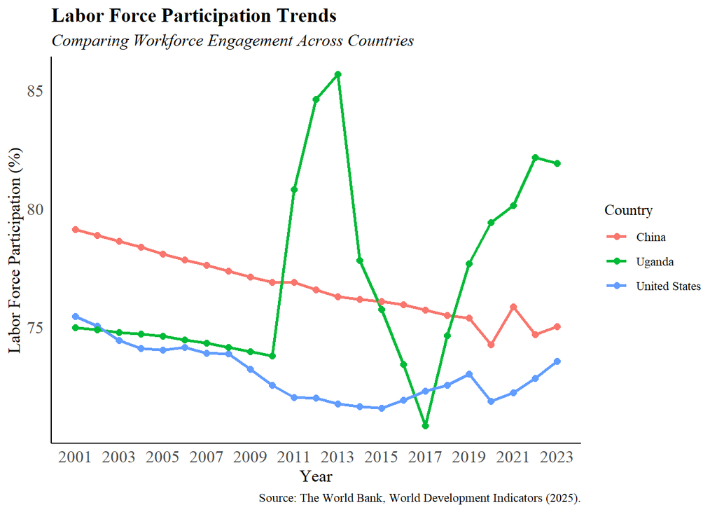

```r
ggplot(data_available_clean, aes(x = year, group = country_name, color = country_name)) +
  geom_line(aes(y = lfpr_total_15_64_milo), size = 1) +
  geom_point(aes(y = lfpr_total_15_64_milo), size = 2) +
  scale_x_continuous(breaks = seq(min(data_available_clean$year), max(data_available_clean$year), by = 2)) +
  labs(
    title = "Labor Force Participation Trends",
    subtitle = "Comparing Workforce Engagement Across Countries",
    x = "Year",
    y = "Labor Force Participation (%)",
    color = "Country",
    caption = "Source: The World Bank, World Development Indicators (2025)."
  ) +
  theme_minimal() +
  theme(
    text = element_text(family = "serif"),
    panel.grid = element_blank(),
    plot.title = element_text(size = 14, face = "bold"),
    plot.subtitle = element_text(size = 12, face = "italic"),
    axis.title.x = element_text(size = 12),
    axis.title.y = element_text(size = 12),
    axis.text.x = element_text(size = 12),
    axis.text.y = element_text(size = 12),
    legend.position = "right",
    axis.line = element_line(color="black")
)
```

## 2. Employment Shifts Across Sectors

While overall labor force participation reflects who is working, analyzing which sectors are driving employment—agriculture, industry, or services—reveals the extent of economic transformation and industrialization.

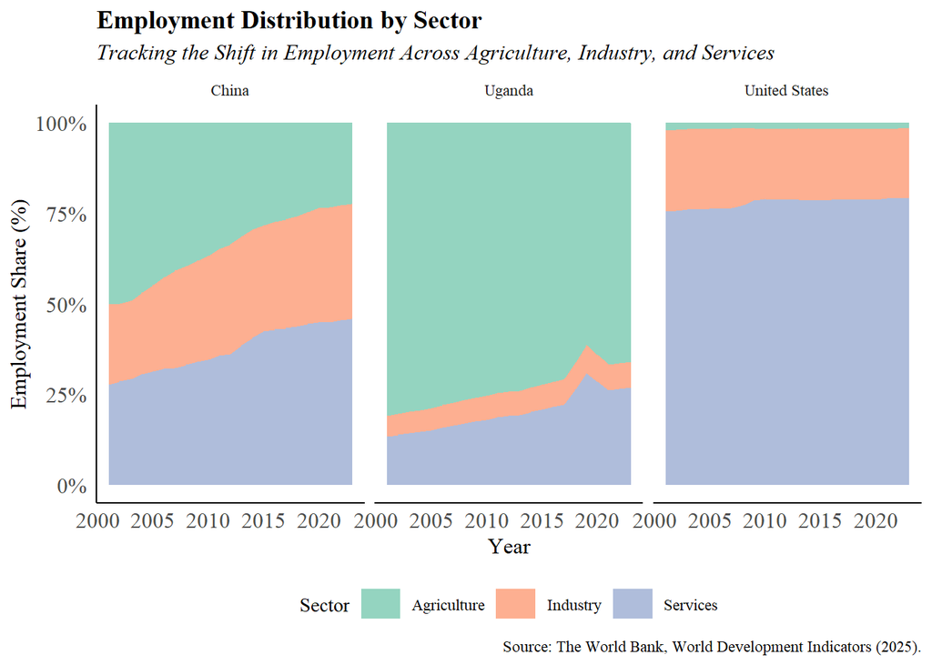

```r
data_available_clean |>
  mutate(total_employment = empl_agri + empl_industry + empl_services) |>
  pivot_longer(cols = c(empl_agri, empl_industry, empl_services),
               names_to = "sector",
               values_to = "employment_rate") |>
  mutate(employment_share = employment_rate / total_employment * 100) |>
  ggplot(aes(x = year, y = employment_share, fill = sector)) +
  geom_area(alpha = 0.7) +
  facet_wrap(~country_name) +
  labs(
    title = "Employment Distribution by Sector",
    subtitle = "Tracking the Shift in Employment Across Agriculture, Industry, and Services",
    x = "Year", y = "Employment Share (%)",
    fill = "Sector",
    caption = "Source: The World Bank, World Development Indicators (2025)."
  ) +
  scale_fill_manual(values = c("empl_agri" = "#66c2a5",
                               "empl_industry" = "#fc8d62",
                               "empl_services" = "#8da0cb"),
                    labels = c("Agriculture", "Industry", "Services")) +
  scale_y_continuous(labels = scales::percent_format(scale = 1)) +
  theme_minimal() +
  theme(
    text = element_text(family = "serif"),
    panel.grid = element_blank(),
    plot.title = element_text(size = 14, face = "bold"),
    plot.subtitle = element_text(size = 12, face = "italic"),
    axis.title.x = element_text(size = 12),
    axis.title.y = element_text(size = 12),
    axis.text.x = element_text(size = 12),
    axis.text.y = element_text(size = 12),
    legend.position = "bottom",
    axis.line = element_line(color = "black"),
    legend.key.width = unit(0.8,"cm")
)
```

## 3. As Employment in Services Increases, Wage Workers Rise.

As economies shift towards a service-oriented workforce, the question remains: does this growth lead to more stable, wage-based jobs, or does informal and precarious employment persist?

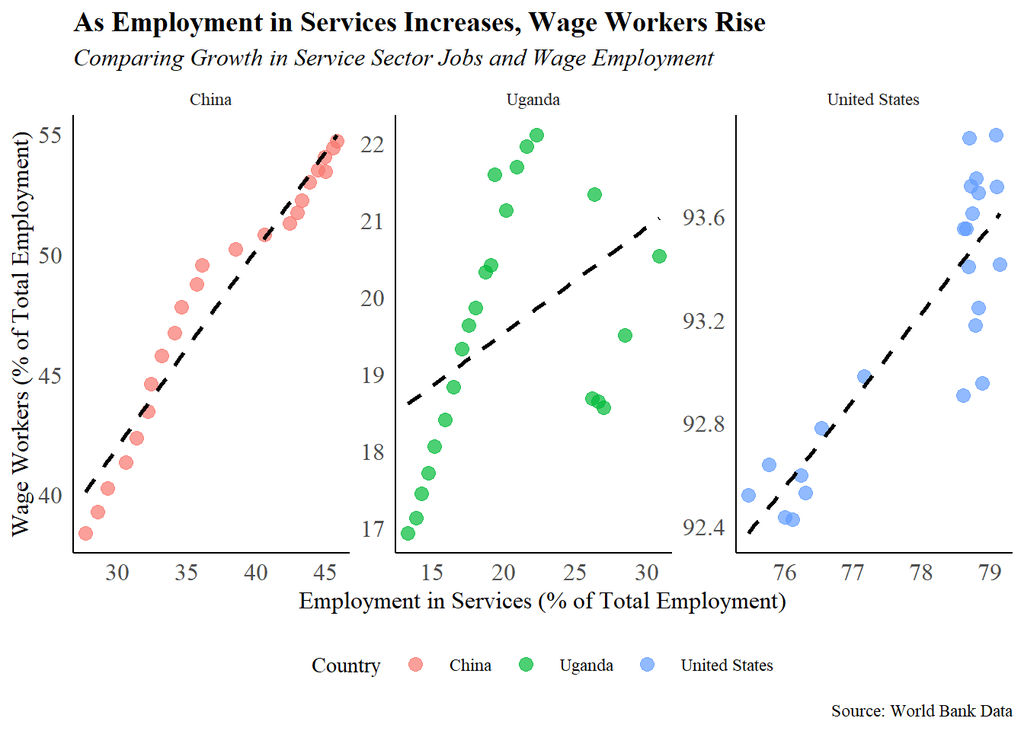

```r
ggplot(data_available_clean, aes(x = empl_services, y = wage_workers_total, color = country_name)) +
  geom_point(size = 3, alpha = 0.7) +  # Scatter points with transparency
  geom_smooth(method = "lm", se = FALSE, linetype = "dashed", color = "black") +  # Trend line per country
  facet_wrap(~country_name, scales = "free") +  # Separate plots for each country
  labs(
    title = "As Employment in Services Increases, Wage Workers Rise",
    subtitle = "Comparing Growth in Service Sector Jobs and Wage Employment",
    x = "Employment in Services (% of Total Employment)",
    y = "Wage Workers (% of Total Employment)",
    color = "Country",
    caption = "Source: World Bank Data"
  ) +
    theme_minimal() +
  theme(
    text = element_text(family = "serif"),
    panel.grid = element_blank(),
    plot.title = element_text(size = 14, face = "bold"),
    plot.subtitle = element_text(size = 12, face = "italic"),
    axis.title.x = element_text(size = 12),
    axis.title.y = element_text(size = 12),
    axis.text.x = element_text(size = 12),
    axis.text.y = element_text(size = 12),
    legend.position = "bottom",
    axis.line = element_line(color = "black"),
    legend.key.width = unit(0.8,"cm")
)
```

The graph illustrates how increasing employment in the service sector correlates with the rise of wage jobs across China, Uganda, and the United States. In China, steady growth in service employment has been accompanied by a consistent rise in wage jobs, reflecting a structured transition to a more formal labor market. In Uganda, while service employment has increased, wage job trends have been unstable, indicating that many service roles remain informal or low-paying. In the United States, where the economy is predominantly service-based, wage employment remains consistently high due to strong labor regulations and the formal nature of most service jobs.

## 4. Wage Employment vs. Household Consumption Growth

Even if wage employment rises, its economic impact depends on whether higher job stability translates into increased household spending, reinforcing sustainable economic growth.

```r
library(ggplot2)
library(dplyr)
library(tidyr)

# Ensure data is correctly reshaped
data_long <- data_available_clean %>%
  select(year, country_name, wage_workers_total, final_cons_growth) %>%
  pivot_longer(cols = c(wage_workers_total, final_cons_growth),
               names_to = "Metric",
               values_to = "Value")  # Ensure this column is correctly created

# Improve labels
data_long$Metric <- recode(data_long$Metric,
                           "wage_workers_total" = "Wage Workers (% of Total Employment)",
                           "final_cons_growth" = "Final Consumption Growth (%)")

# Check the structure of data to ensure 'Value' exists
print(head(data_long))
```

```
# A tibble: 6 × 4
   year country_name  Metric                               Value
  <dbl> <chr>         <chr>                                <dbl>
1  2001 United States Wage Workers (% of Total Employment) 92.5
2  2001 United States Final Consumption Growth (%)          2.67
3  2002 United States Wage Workers (% of Total Employment) 92.6
4  2002 United States Final Consumption Growth (%)          2.78
5  2003 United States Wage Workers (% of Total Employment) 92.4
6  2003 United States Final Consumption Growth (%)          2.90
```

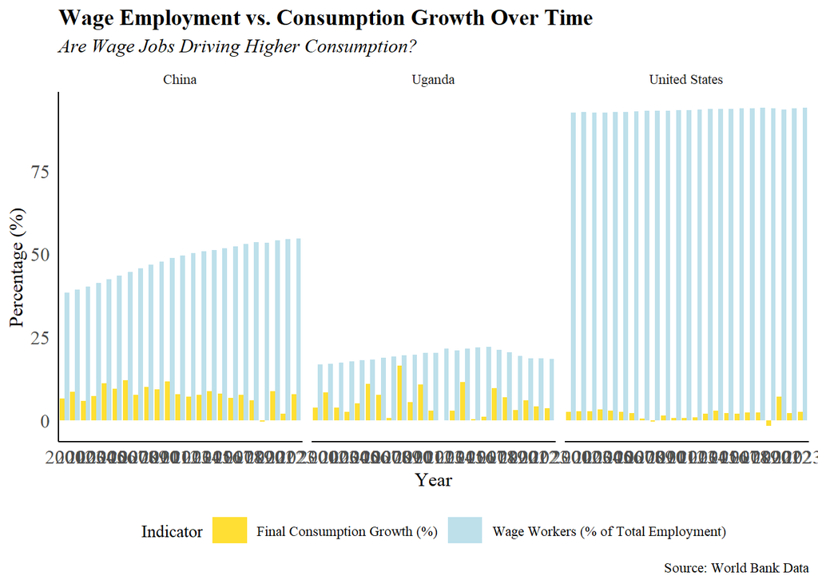

```r
# Create bar graph
ggplot(data_long, aes(x = factor(year), y = Value, fill = Metric)) +  # Convert year to factor for discrete x-axis
  geom_col(position = "dodge", alpha = 0.8) +
  facet_wrap(~country_name) +  # Create separate plots per country
  scale_fill_manual(values = c("Wage Workers (% of Total Employment)" = "lightblue",
                               "Final Consumption Growth (%)" = "gold")) +
  labs(
    title = "Wage Employment vs. Consumption Growth Over Time",
    subtitle = "Are Wage Jobs Driving Higher Consumption?",
    x = "Year",
    y = "Percentage (%)",
    fill = "Indicator",
    caption = "Source: World Bank Data"
  ) +
    theme_minimal() +
  theme(
    text = element_text(family = "serif"),
    panel.grid = element_blank(),
    plot.title = element_text(size = 14, face = "bold"),
    plot.subtitle = element_text(size = 12, face = "italic"),
    axis.title.x = element_text(size = 12),
    axis.title.y = element_text(size = 12),
    axis.text.x = element_text(size = 12),
    axis.text.y = element_text(size = 12),
    legend.position = "bottom",
    axis.line = element_line(color = "black"),  # Ensures both x-axis and y-axis lines are visible
    legend.key.width = unit(0.8,"cm")
)
```

The graph explores whether an increase in wage employment leads to higher household consumption across China, Uganda, and the United States. In China, wage employment has grown steadily, but consumption growth remains moderate, suggesting that rising wages or job stability may be necessary to boost spending. In Uganda, wage employment and consumption growth are both volatile, indicating that many jobs remain low-paying or informal, limiting their impact on household spending. In the United States, where wage employment is consistently high, consumption growth remains stable, reflecting a strong link between formal employment, financial security, and sustained consumer demand.

## Policy recommendation

Whereas employment in services increases wage workers, it may not necessarily lead to higher household consumption, as shown across the four graphs. In China and Uganda, rising service sector employment has not consistently translated into higher consumption, suggesting that low wages and job instability limit spending power. In contrast, the United States demonstrates that stable wage employment supports sustained consumption growth, highlighting the importance of job quality and fair wages. Therefore, policymakers should ensure wage growth aligns with productivity, strengthen labor protections, and implement policies that boost disposable income to drive household consumption and economic growth.